# Integrate_annotation_Xenium_reference

Sifan Zhang

2024-12-02

**This .Rmd will go through how to load and integrate public datasets from NCBI and write integrated seurat object into format required by Xenium Custom Panel Designer.**

**The reason we are doing this: The features.tsv.gv file contains two coloums, ensmble ID and gene ID, the default setting of read10x funtion is to use gene ID as gene name because it makes more biological sense. But if you need to write MEX file in a later point (for example, use it as a reference dataset for Xenium panel designer), you will need ensmble ID.**

**The aim of this workflow is to store full gene info including ensembl ID and gene ID in assays$RNA@meta.data, which used to be meta.features in seurat v3. So the DropletUtils package can work properly to write a integrated seurat object to MEX format.**

**One thing to know before doing this: you may want to upload single, pre-QC datasets if you want all genes to be there. In this case you can jump batch loading sample, QC and integration, just annotate samples one by one, and write MEX files for multiple reference datasets. The maximum datasets for Xenium panel designer is 5. If you want a reference dataset that can include comprehensive clusters, you can integrate the samples and upload it as one reference dataset**

# Prepare r packages

Note that “SeuratObject” and “Seurat” are necessary for processing 10x single cell dataset to a seurat object.

“GEOquery” need to be downloaded from BiocManager first, it’s for read raw data from NCBI database.

“DropletUtils” need to be downloaded from BiocManager first, it’s for writing seurat object back to MEX format that Xenium requires.

“harmony” is for data integration.

```r
library(devtools)
library(remotes)
library(DropletUtils)
library(GEOquery)
library(SeuratObject)
library(Seurat)
library(Matrix)
library(ggplot2)
library(cowplot)
library(dplyr)
library(harmony)
library(tidyr)
library(RColorBrewer)
```

# Set up R environment

including working directory, this depends on your own laptop. For MacOs users you can just copy and paste working directory, for Windows users you need to change backslash to forward slash

```r
knitr::opts_chunk$set(echo = TRUE, message=F, warning=F)

# sets the directory of all chunks to the directory of this script
knitr::opts_knit$set(root.dir = "M:/SifanZ/OneDrive - Westmead Institute for Medical Research/Data/scRNA_LN/GSE254435")

theme_set(theme_classic())
set.seed(1337)
```

The data is derived from [Fine needle aspiration of human lymph nodes](https://onlinelibrary.wiley.com/doi/full/10.1002/eji.202350872).

## Downloading and loading data into Seurat

```r
pDir = getwd()
if(!dir.exists("raw")){dir.create("raw")}
if(!dir.exists("data")){dir.create("data")}

#download the data from the GEO
download.file("https://www.ncbi.nlm.nih.gov/geo/download/?acc=GSE254435&format=file",
             destfile = "GSE254435.tar",
             method = "curl")

#untar data into a new folder called "raw"
untar("GSE254435.tar", exdir = "raw")
```

# Collect the submitted metadata for each sample

```r
gse <- pData(GEOquery::getGEO("GSE254435")[[1]])
gse$donor <- sub(".*donor (\\d+)", "donor \\1", gse$title)
saveRDS(gse, "data/gse,rds")
```

# Create a new folder for data and load in the names of the files we downloaded

```r
mats = list.files("raw/", pattern= ".mtx")
bars = list.files("raw/", pattern= ".barcode")
feats = list.files("raw/", pattern= ".feat")
```

# Load multiple data

```r
setwd("raw")
seu_list <- list()
for(i in 1:nrow(gse)){

  mat = readMM(grep(rownames(gse)[i], mats, value=T))
  feat = read.delim(grep(rownames(gse)[i], feats, value=T), header=F)
  bar = read.delim(grep(rownames(gse)[i], bars, value=T), header=F)

  feat$V4 <- make.unique(feat$V2, sep="-")

  rownames(mat) <- feat$V4 #rownames = genes
  colnames(mat) <- bar$V1 #colnames = barcodes

  #generate the metadata file using information from the gse object
  met <- data.frame(row.names = bar$V1)
  met$sample <- gse$`title`[i]
  met$tissue <- gse$`tissue:ch1`[i]
  met$donor <- gse$`donor`[i]

  #create seurat object
  seu <- CreateSeuratObject(mat, meta.data = met)

  # feature metadata
  seu@assays$RNA@meta.data
  seu@assays$RNA@meta.data$geneID <- feat$V2
  seu@assays$RNA@meta.data$geneID_Unique <- feat$V4
  seu@assays$RNA@meta.data$ensembl <- feat$V1

  seu$percent.mt <- PercentageFeatureSet(seu, features=rownames(seu)[grep("MT-", seu@assays$RNA@meta.data$geneID)])
  #  number of genes and number of transcripts
  seu$filter = ifelse(seu$nCount_RNA>900 & seu$nFeature_RNA>1300 & seu$percent.mt<6.5,
                      "keep",
                      'throw')

  seu <- subset(seu, subset = filter == "keep")
  seu_list[[i]] <- seu
}
seu <- Reduce(function(x, y) merge(x, y), seu_list)

#rm(bar,feat,mat,met, bars, feats, i, mats, zeroes)
setwd(pDir)
seu[["RNA"]] <- JoinLayers(seu[["RNA"]])

zeroes <- rowSums(seu@assays$RNA@layers$counts!=0) # counts the number of non-zeros per row.
seu <- seu[zeroes>=10,]

saveRDS(seu, "data/all_data_unint.rds")
```

```r
data <- readRDS("data/all_data_unint.rds")
data
```

```
## An object of class Seurat
## 22198 features across 19687 samples within 1 assay
## Active assay: RNA (22198 features, 0 variable features)
##  1 layer present: counts
```

```r
head(data@meta.data)
```

```
##                             orig.ident nCount_RNA nFeature_RNA         sample
## AAACCTGCAGACGCTC-1_1_1_1 SeuratProject       9435         2826 Blood, donor 1
## AAACCTGGTCTCTTTA-1_1_1_1 SeuratProject       9396         3074 Blood, donor 1
## AAACGGGAGATGGCGT-1_1_1_1 SeuratProject      17748         2766 Blood, donor 1
## AAACGGGCAAACGCGA-1_1_1_1 SeuratProject      25129         4108 Blood, donor 1
## AAACGGGGTCTGCCAG-1_1_1_1 SeuratProject      15509         2744 Blood, donor 1
## AAAGATGAGGTAGCTG-1_1_1_1 SeuratProject      18884         3448 Blood, donor 1
##                                    tissue   donor percent.mt filter
## AAACCTGCAGACGCTC-1_1_1_1 peripheral blood donor 1  1.8335983   keep
## AAACCTGGTCTCTTTA-1_1_1_1 peripheral blood donor 1  1.7667092   keep
## AAACGGGAGATGGCGT-1_1_1_1 peripheral blood donor 1  0.5183683   keep
## AAACGGGCAAACGCGA-1_1_1_1 peripheral blood donor 1  0.7879343   keep
## AAACGGGGTCTGCCAG-1_1_1_1 peripheral blood donor 1  0.9155974   keep
## AAAGATGAGGTAGCTG-1_1_1_1 peripheral blood donor 1  1.4509638   keep
```

```r
head(data@assays$RNA@meta.data)
```

```
##        geneID geneID_Unique         ensembl
## 4  AL627309.1    AL627309.1 ENSG00000238009
## 7  AL627309.5    AL627309.5 ENSG00000241860
## 9  AP006222.2    AP006222.2 ENSG00000286448
## 15  LINC01409     LINC01409 ENSG00000237491
## 16     FAM87B        FAM87B ENSG00000177757
## 17  LINC01128     LINC01128 ENSG00000228794
```

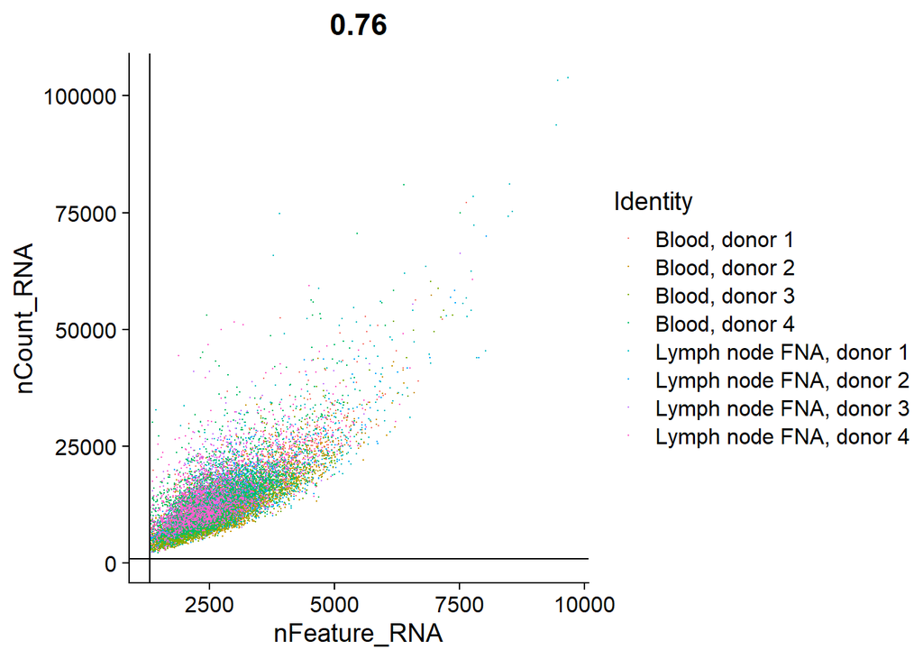

```r
FeatureScatter(data, "nFeature_RNA", "nCount_RNA", group.by='sample', pt.size=0.1)+
  geom_vline(xintercept = 1300)+
  geom_hline(yintercept = 900)
```

# Performing the integration

here, we’ll use harmony and integrate per donor, dims=45, resolution = 1.2 because its what the paper use. Just to reproduce the figure. Integration using Seurat v5 can be found in https://satijalab.org/seurat/articles/seurat5_integration

```r
options(future.globals.maxSize = 3 * 1024^3)  # 3 GiB

data[["RNA"]] <- split(data[["RNA"]], f = data$donor)

data <- NormalizeData(data,verbose=F)
data <- FindVariableFeatures(data,verbose=F)
data <- ScaleData(data,verbose=F)
data <- RunPCA(data,verbose=F)

# checking unintegrated analysis
data <- FindNeighbors(data, dims = 1:45, reduction = "pca",verbose=F)
data <- FindClusters(data, resolution = 1.2, cluster.name = "unintegrated_clusters",verbose=F)
data <- RunUMAP(data, dims = 1:45, reduction = "pca", reduction.name = "umap.unintegrated",verbose=F)
#integrating data
data <- IntegrateLayers(object = data, method = HarmonyIntegration, orig.reduction = "pca", new.reduction = "harmony",
    verbose = T)
data[["RNA"]] <- JoinLayers(data[["RNA"]])

data <- FindNeighbors(data, reduction = "harmony", dims = 1:45,verbose=F)
data <- FindClusters(data, resolution = 1.2,verbose=F)
data <- RunUMAP(data, dims = 1:45, reduction = "harmony",verbose=F)


saveRDS(data,"data/integrated.rds")
```

# Comparison between unintegrated vs. integrated

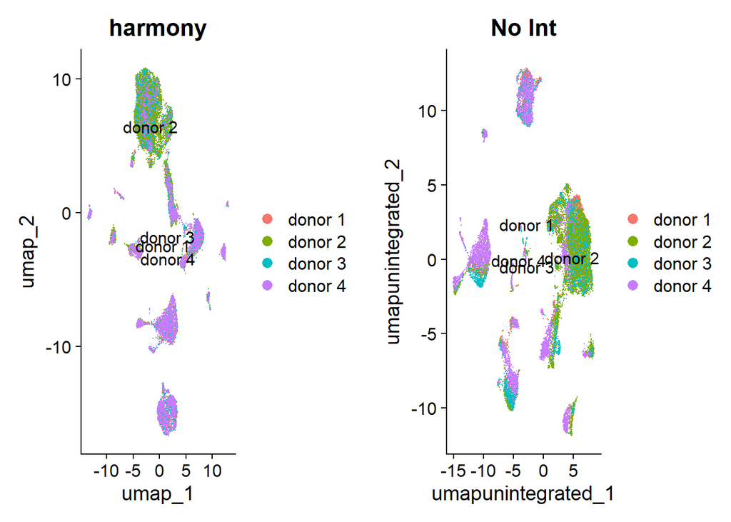

```r
data <- readRDS("data/integrated.rds")

plot_grid(
  DimPlot(data, reduction = "umap", group.by = "donor", label=T)+ggtitle("harmony"),
  DimPlot(data, reduction = "umap.unintegrated", group.by = "donor", label=T)+ggtitle("No Int")
)
```

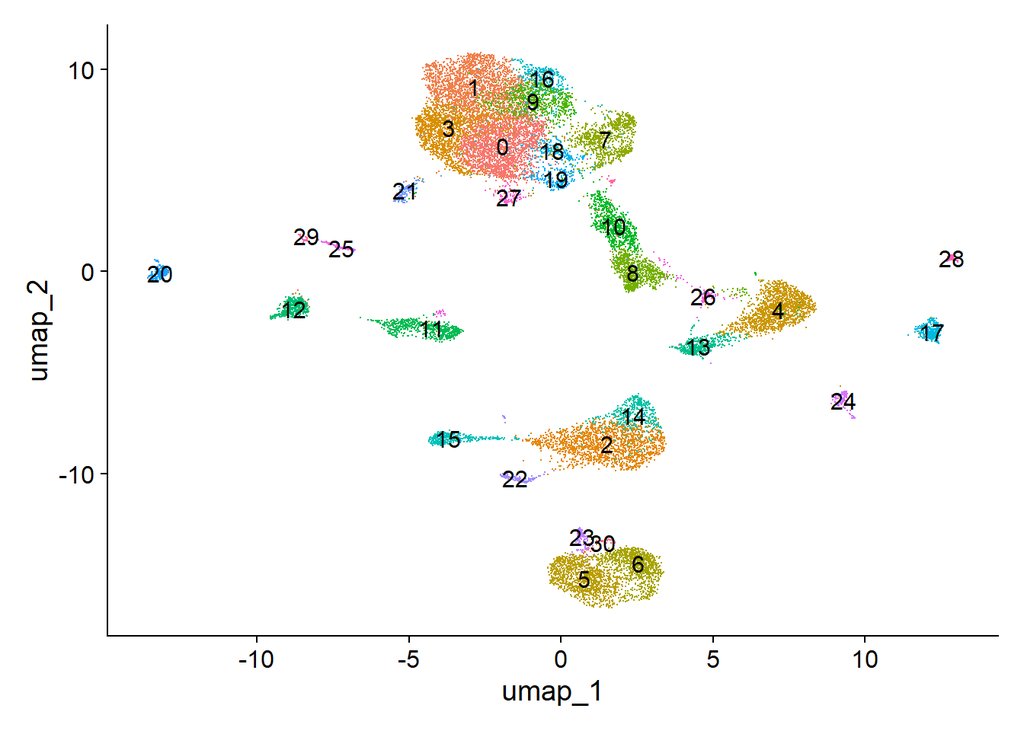

```r
  DimPlot(data, reduction = "umap", label=T)+NoLegend()
```

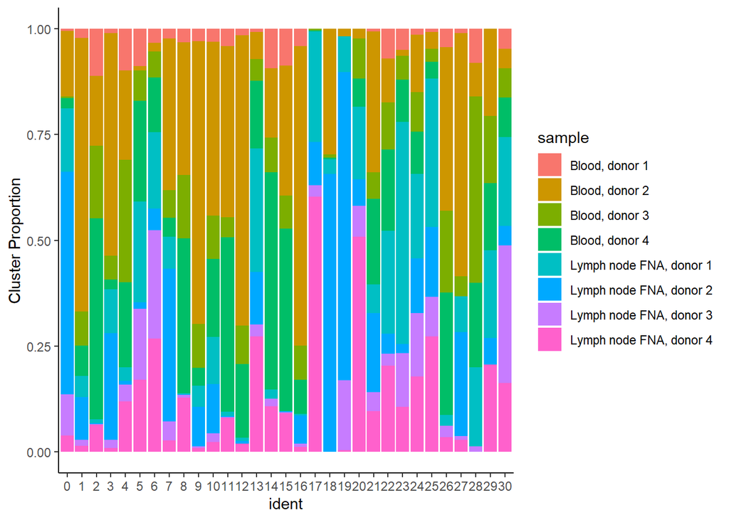

```r
FetchData(data, c("ident","sample")) %>% group_by(ident) %>%
    mutate(prop=1/length(ident)) %>%
    ungroup() %>%
    group_by(ident,sample) %>%
    summarise(totprop=sum(prop), .groups = "drop") %>%
    ggplot(aes(x=ident,fill=sample,y=totprop)) +
    geom_bar(position='fill', stat='identity') +
    theme(axis.text.x =element_text(angle = 45,hjust=1))+scale_y_continuous(name="Cluster Proportion")+ theme_classic()
```

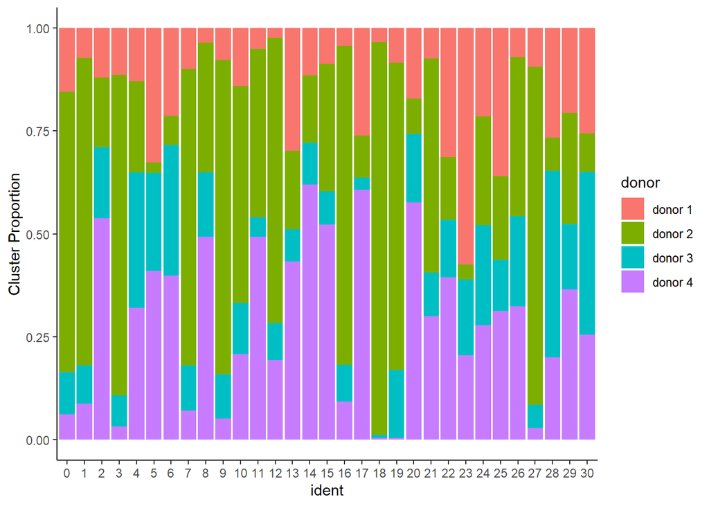

```r
FetchData(data, c("ident","donor")) %>% group_by(ident) %>%
    mutate(prop=1/length(ident)) %>%
    ungroup() %>%
    group_by(ident,donor) %>%
    summarise(totprop=sum(prop),.groups = "drop") %>%
    ggplot(aes(x=ident,fill=donor,y=totprop)) +
    geom_bar(position='fill', stat='identity') +
    theme(axis.text.x =element_text(angle = 45,hjust=1))+scale_y_continuous(name="Cluster Proportion")+ theme_classic()
```

# Use Dotplot to visualize gene expression, and annotate clusters

note: always set default assay to ‘RNA’ when looking at gene expression From the UMAP we can see the current resolution can’t seperate cDC1 and cDC2, needs to be improved later

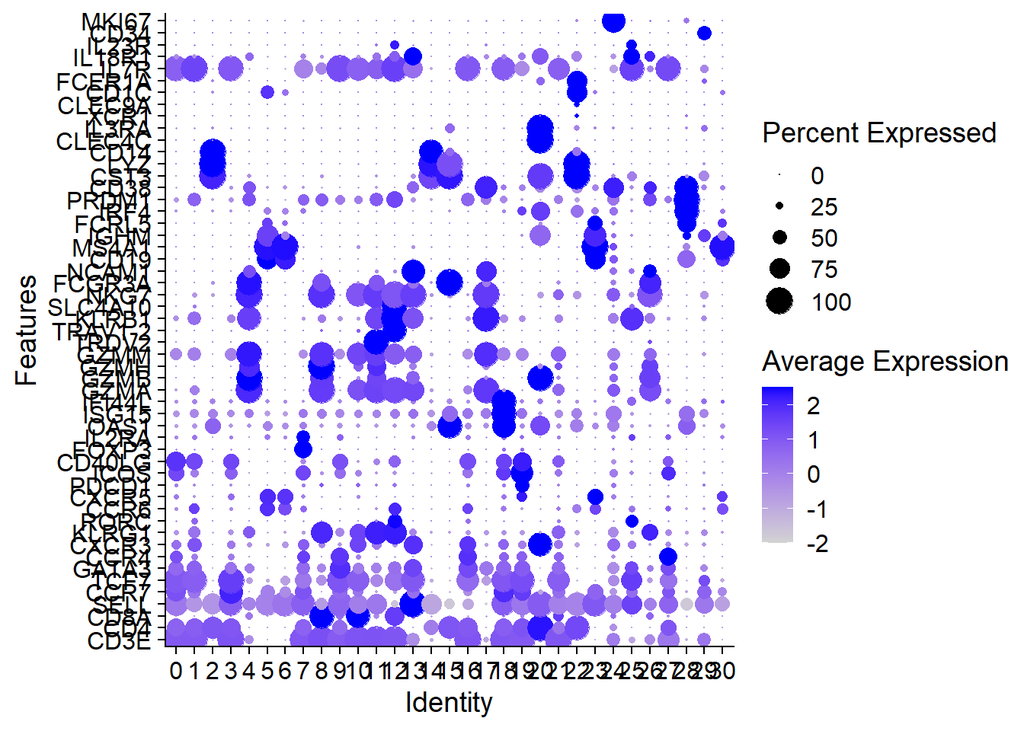

```r
DefaultAssay(data) <- "RNA"
Markers <- c('CD3E','CD4','CD8A','SELL','CCR7','TCF7','GATA3','CCR4','CXCR3','KLRG1','RORC','CCR6','CXCR5','PDCD1','ICOS',
            'CD40LG','FOXP3','IL2RA','OAS1','ISG15','IFI44L','GZMA','GZMB','GZMH','GZMM','TRDV2','TRAV1-2','KLRB1','SLC4A10',
            'NKG7', 'FCGR3A','NCAM1','CD19','MS4A1','IGHM','FCRL5','IRF4','PRDM1','CD38','CST3','LYZ','CD14','CLEC4C','IL3RA',
            'XCR1', 'CLEC9A','CD1C','FCER1A','IL7R','IL18R1','IL23R','CD34','MKI67')
DotPlot(data, features = Markers) +coord_flip()
```

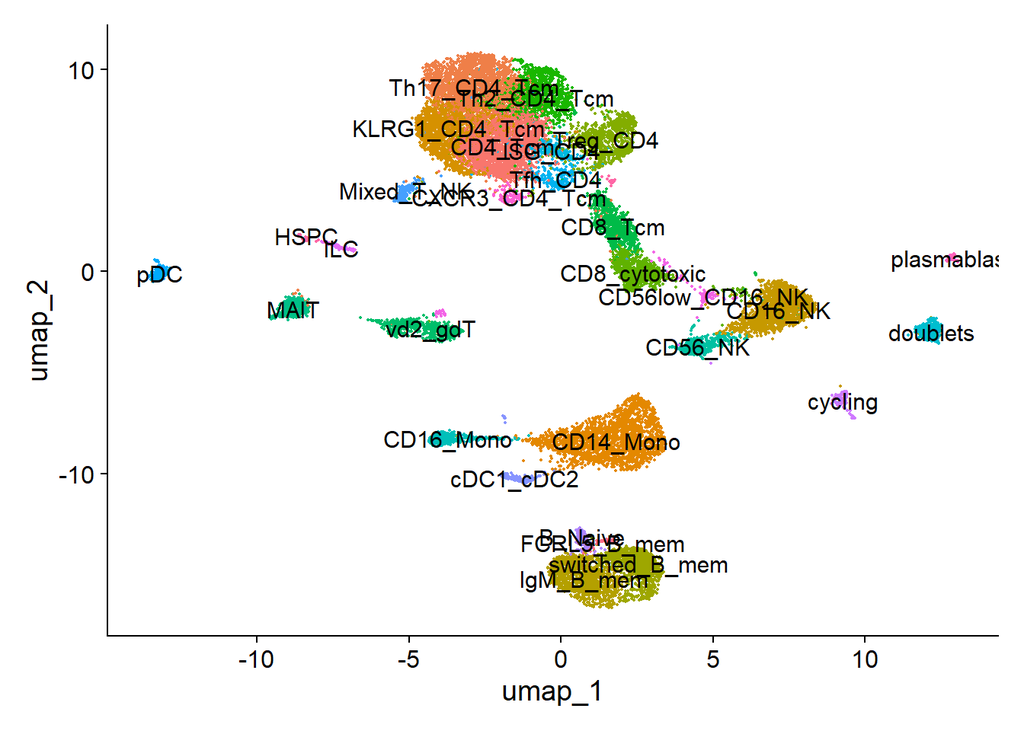

```r
new.cluster.ids <- c(`0` = "CD4_Tcm",
                     `1` = "Th17_CD4_Tcm",
                     `2` = "CD14_Mono",
                     `3` = "KLRG1_CD4_Tcm",
                     `4` = "CD16_NK",
                     `5` = "IgM_B_mem",
                     `6` = "switched_B_mem",
                     `7` = "Treg_CD4",
                     `8` = "CD8_cytotoxic",
                     `9` = "Th2_CD4_Tcm",
                     `10` = "CD8_Tcm",
                     `11` = "vd2_gdT",
                     `12` = "MAIT",
                     `13` = "CD56_NK",
                     `14` = "CD14_Mono",
                     `15` = "CD16_Mono",
                     `16` = "Th2_CD4_Tcm",
                     `17` = "doublets",
                     `18` = "ISG_CD4",
                     `19` = "Tfh_CD4",
                     `20` = "pDC",
                     `21` = "Mixed_T_NK",
                     `22` = "cDC1_cDC2",
                     `23` = "B_Naive",
                     `24` = "cycling",
                     `25` = "ILC",
                     `26` = "CD56low_CD16_NK",
                     `27` = "CXCR3_CD4_Tcm",
                     `28` = "plasmablast",
                     `29` = "HSPC",
                     `30` = "FCRL5_B_mem"
                     )
names(new.cluster.ids) <- levels(data)
data <- RenameIdents(data, new.cluster.ids)
DimPlot(data, reduction = "umap", label = TRUE, pt.size = 0.3) + NoLegend()
```

```r
head(data@meta.data)
```

```
##                             orig.ident nCount_RNA nFeature_RNA         sample
## AAACCTGCAGACGCTC-1_1_1_1 SeuratProject       9435         2826 Blood, donor 1
## AAACCTGGTCTCTTTA-1_1_1_1 SeuratProject       9396         3074 Blood, donor 1
## AAACGGGAGATGGCGT-1_1_1_1 SeuratProject      17748         2766 Blood, donor 1
## AAACGGGCAAACGCGA-1_1_1_1 SeuratProject      25129         4108 Blood, donor 1
## AAACGGGGTCTGCCAG-1_1_1_1 SeuratProject      15509         2744 Blood, donor 1
## AAAGATGAGGTAGCTG-1_1_1_1 SeuratProject      18884         3448 Blood, donor 1
##                                    tissue   donor percent.mt filter
## AAACCTGCAGACGCTC-1_1_1_1 peripheral blood donor 1  1.8335983   keep
## AAACCTGGTCTCTTTA-1_1_1_1 peripheral blood donor 1  1.7667092   keep
## AAACGGGAGATGGCGT-1_1_1_1 peripheral blood donor 1  0.5183683   keep
## AAACGGGCAAACGCGA-1_1_1_1 peripheral blood donor 1  0.7879343   keep
## AAACGGGGTCTGCCAG-1_1_1_1 peripheral blood donor 1  0.9155974   keep
## AAAGATGAGGTAGCTG-1_1_1_1 peripheral blood donor 1  1.4509638   keep
##                          unintegrated_clusters seurat_clusters RNA_snn_res.1.2
## AAACCTGCAGACGCTC-1_1_1_1                    11               8               8
## AAACCTGGTCTCTTTA-1_1_1_1                     4               4               4
## AAACGGGAGATGGCGT-1_1_1_1                     1              14              14
## AAACGGGCAAACGCGA-1_1_1_1                     1               2               2
## AAACGGGGTCTGCCAG-1_1_1_1                     7               3               3
## AAAGATGAGGTAGCTG-1_1_1_1                     3               1               1
```

# Subcluster DCs

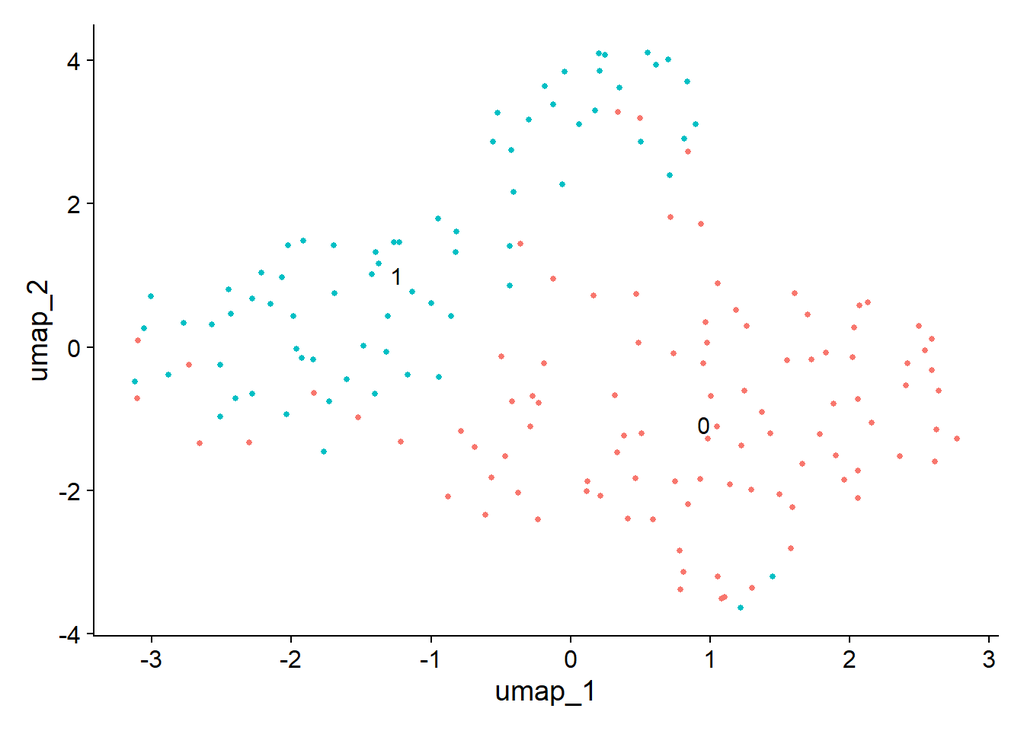

```r
sub.cells <- subset(data, idents = "cDC1_cDC2")
f = "obj.Rdata"
if(!file.exists(f)){
  sub.cells = sub.cells %>%
  NormalizeData() %>%
  FindVariableFeatures() %>%
  ScaleData(features = rownames(.)) %>%
  RunPCA(features = VariableFeatures(.))  %>%
  FindNeighbors(dims = 1:45) %>%
  FindClusters(resolution = 0.5) %>%
  RunUMAP(dims = 1:45)
  save(sub.cells,file = f)
}
load(f)
DimPlot(sub.cells, reduction = 'umap',label = T)+NoLegend()
```

```r
sub.cells
```

```
## An object of class Seurat
## 22198 features across 172 samples within 1 assay
## Active assay: RNA (22198 features, 2000 variable features)
##  3 layers present: data, counts, scale.data
##  4 dimensional reductions calculated: pca, umap.unintegrated, harmony, umap
```

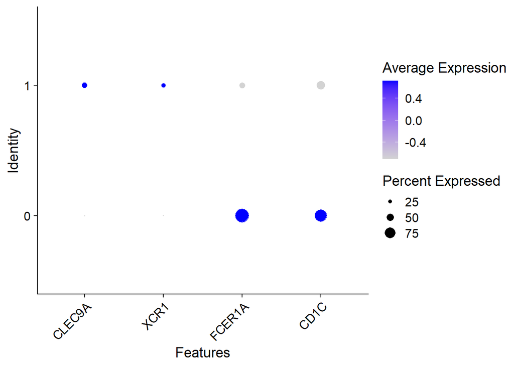

```r
#Visualize marker genes
DefaultAssay(sub.cells)<-"RNA"
DC_markers<-c('CLEC9A','XCR1','FCER1A','CD1C')
DotPlot(sub.cells,features = DC_markers) + RotatedAxis()
```

```r
#Annotate and put back to big umap
sub.cells@meta.data$annotation <- ifelse(sub.cells@meta.data$seurat_clusters == 0, "cDC2", "cDC1")
head(sub.cells@meta.data)
```

```
##                             orig.ident nCount_RNA nFeature_RNA         sample
## ATTGGACCACGGATAG-1_1_1_1 SeuratProject      35038         5857 Blood, donor 1
## CAAGGCCGTGTGCCTG-1_1_1_1 SeuratProject      30235         5353 Blood, donor 1
## CACTCCAAGCGATCCC-1_1_1_1 SeuratProject      28323         4825 Blood, donor 1
## CAGCCGAAGGTGTGGT-1_1_1_1 SeuratProject      38982         6680 Blood, donor 1
## CCACGGACAAAGGCGT-1_1_1_1 SeuratProject      24264         4737 Blood, donor 1
## CCTTACGTCTTTACGT-1_1_1_1 SeuratProject      25173         5157 Blood, donor 1
##                                    tissue   donor percent.mt filter
## ATTGGACCACGGATAG-1_1_1_1 peripheral blood donor 1   1.549746   keep
## CAAGGCCGTGTGCCTG-1_1_1_1 peripheral blood donor 1   1.012072   keep
## CACTCCAAGCGATCCC-1_1_1_1 peripheral blood donor 1   1.066271   keep
## CAGCCGAAGGTGTGGT-1_1_1_1 peripheral blood donor 1   1.611000   keep
## CCACGGACAAAGGCGT-1_1_1_1 peripheral blood donor 1   1.854599   keep
## CCTTACGTCTTTACGT-1_1_1_1 peripheral blood donor 1   2.709252   keep
##                          unintegrated_clusters seurat_clusters RNA_snn_res.1.2
## ATTGGACCACGGATAG-1_1_1_1                    21               0              22
## CAAGGCCGTGTGCCTG-1_1_1_1                    21               0              22
## CACTCCAAGCGATCCC-1_1_1_1                    21               0              22
## CAGCCGAAGGTGTGGT-1_1_1_1                    21               0              22
## CCACGGACAAAGGCGT-1_1_1_1                    21               0              22
## CCTTACGTCTTTACGT-1_1_1_1                    21               0              22
##                          RNA_snn_res.0.5 annotation
## ATTGGACCACGGATAG-1_1_1_1               0       cDC2
## CAAGGCCGTGTGCCTG-1_1_1_1               0       cDC2
## CACTCCAAGCGATCCC-1_1_1_1               0       cDC2
## CAGCCGAAGGTGTGGT-1_1_1_1               0       cDC2
## CCACGGACAAAGGCGT-1_1_1_1               0       cDC2
## CCTTACGTCTTTACGT-1_1_1_1               0       cDC2
```

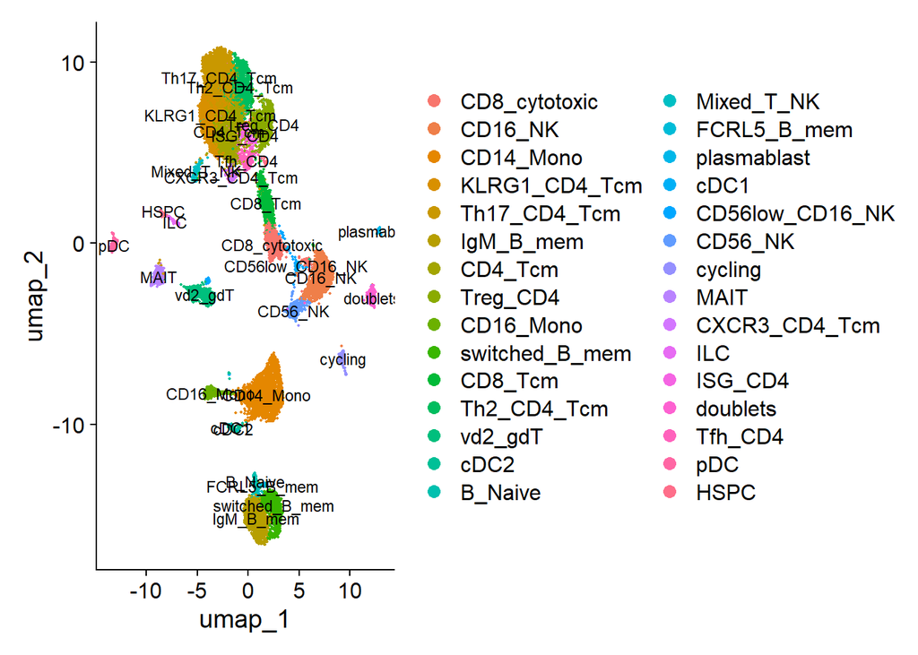

```r
data@meta.data$annotation = as.character(Idents(data))
data@meta.data$annotation = ifelse(data@meta.data$annotation=="cDC1_cDC2",
       sub.cells@meta.data$annotation[match(colnames(data@meta.data),colnames(sub.cells@meta.data))],
       data@meta.data$annotation)
Idents(data) = data@meta.data$annotation
DimPlot(data,reduction = "umap", label = T, pt.size = 0.3, label.size = 3)
```

```r
table(data@meta.data$annotation)
```

```
##
##         B_Naive       CD14_Mono       CD16_Mono         CD16_NK         CD4_Tcm
##             141            2101             371            1493            2209
##         CD56_NK CD56low_CD16_NK   CD8_cytotoxic         CD8_Tcm            cDC1
##             432             114             876             766              20
##            cDC2   CXCR3_CD4_Tcm         cycling        doublets     FCRL5_B_mem
##             152             106             140             333              43
##            HSPC       IgM_B_mem             ILC         ISG_CD4   KLRG1_CD4_Tcm
##              63            1216             128             260            1624
##            MAIT      Mixed_T_NK             pDC     plasmablast  switched_B_mem
##             466             177             222              75             976
##         Tfh_CD4    Th17_CD4_Tcm     Th2_CD4_Tcm        Treg_CD4         vd2_gdT
##             225            2147            1203             915             693
```

```r
saveRDS(data,"data/alldata_annotated.rds")
```

#Subset Lymph node data for Xenium reference

```r
LN <- subset(data, subset = tissue == "lymph node")
saveRDS(LN,"data/LN_annotated.rds")
```

# Write Lymph node data to MEX format and export annotation

You can find guideline here [Creating single cell references for Xenium Custom Panel Design from Seurat or AnnData](https://www.10xgenomics.com/analysis-guides/creating-single-cell-references-for-xenium-custom-panel-design-from-seurat-or-anndata)

```r
LN <- readRDS("data/LN_annotated.rds")

DefaultAssay(LN)<-"RNA"
all.equal(GetAssayData(object=LN, assay="RNA", slot="counts")@x, as.integer(GetAssayData(object=LN, assay="RNA", slot="counts")@x))
```

```
## [1] TRUE
```

```r
head(GetAssayData(object=LN, assay="RNA", layer="counts")@x)
```

```
## [1] 1 1 2 1 1 1
```

```r
head(LN@assays$RNA@meta.data$ensembl)
```

```
## [1] "ENSG00000238009" "ENSG00000241860" "ENSG00000286448" "ENSG00000237491"
## [5] "ENSG00000177757" "ENSG00000228794"
```

```r
dplyr::glimpse(GetAssay(LN)@meta.data)
```

```
## Rows: 22,198
## Columns: 29
## $ geneID                                      <chr> "AL627309.1", "AL627309.5"…
## $ geneID_Unique                               <chr> "AL627309.1", "AL627309.5"…
## $ ensembl                                     <chr> "ENSG00000238009", "ENSG00…
## $ vf_vst_counts.donor_1_mean                  <dbl> 0.027529762, 0.058407738, …
## $ vf_vst_counts.donor_1_variance              <dbl> 0.029759136, 0.066925934, …
## $ vf_vst_counts.donor_1_variance.expected     <dbl> 0.040100753, 0.092036878, …
## $ vf_vst_counts.donor_1_variance.standardized <dbl> 0.7421091, 0.7271643, 0.90…
## $ vf_vst_counts.donor_1_variable              <lgl> FALSE, FALSE, FALSE, FALSE…
## $ vf_vst_counts.donor_1_rank                  <int> NA, NA, NA, NA, NA, NA, NA…
## $ vf_vst_counts.donor_2_mean                  <dbl> 0.0090798361, 0.0285682649…
## $ vf_vst_counts.donor_2_variance              <dbl> 0.0089983891, 0.0315204195…
## $ vf_vst_counts.donor_2_variance.expected     <dbl> 0.0117672116, 0.0384274499…
## $ vf_vst_counts.donor_2_variance.standardized <dbl> 0.7647002, 0.8202579, 0.95…
```

[output cut: 16 more lines]

```r
write10xCounts(
  "reference_data",
  GetAssayData(LN, assay = "RNA", layer="counts"),
  gene.id = LN@assays$RNA@meta.data$ensembl,
  gene.symbol = LN@assays$RNA@meta.data$geneID,
  barcodes = colnames(LN),
  type = "sparse",
  version = "3"
)

metadata <- LN@meta.data
output <- data.frame(Barcode = rownames(metadata),
                     Annotation = metadata$annotation)
head(output)
```

```
##                    Barcode     Annotation
## 1 AAACCTGCAATCAGAA-1_1_1_1        CD4_Tcm
## 2 AAACCTGTCCCTGACT-1_1_1_1  KLRG1_CD4_Tcm
## 3 AAACCTGTCCTCAATT-1_1_1_1        CD4_Tcm
## 4 AAACCTGTCCTTTACA-1_1_1_1 switched_B_mem
## 5 AAACCTGTCGTGGTCG-1_1_1_1 switched_B_mem
## 6 AAACGGGAGGACAGAA-1_1_1_1    FCRL5_B_mem
```

```r
write.csv(output, file = "reference_data/cell_type_annotations.csv", row.names = FALSE)
list.files("reference_data")
```

```
## [1] "barcodes.tsv.gz"           "cell_type_annotations.csv"
## [3] "features.tsv.gz"           "matrix.mtx.gz"
```